# MEPS_reproduce_2

Andrew Edwards

Main simulation results for MEPS paper, from fitting maximum likelihood value (and confidence interval) of $b$ for each combination of 10,000 simulated data sets, four binning methods and two fitting methods (MLEmid or MLEbin). Reproduces MEPS Figures 4 and 5 and Table S.3. Then does the same analyses with $x$<sub>min</sub>$=16$ (Figures S.35 and S.36 and Table S.4), and with $x$<sub>min</sub>$=1$ but only sampling above a cutoff value of 16 (Figures S.37 and S.38 and Table S.5).

The simulated data take over an hour (on a fast laptop) to generate, bin and fit. So results are saved within the package in the lists `MLEbin.MEPS.default`, `MLEbin.MEPS.xmin16` and `MLEbin.MEPS.cutoff16`. Each list contains the fitted maximum likelihood value (and confidence interval) of $b$ for each combination of 10,000 simulated data sets, four binning methods and two fitting methods (MLEmid or MLEbin).

```r
library(sizeSpectra)
```

## Reproducing main simulation results of MEPS paper – Figures 4 and 5 and Table S.3

To create `MLEbin.MEPS.default` run the next line (which is not evaluated by this vignette but is run once in `data-raw/simulate-data2.R` to save the list as part of this package):

```r
MLEbin.MEPS.default <- MLEbin.simulate()
```

The list contains three items (see `?MLEbin.simulate`):

```r
summary(MLEbin.MEPS.default)
```

```
#>                      Length Class  Mode
#> MLE.array             80000 -none- numeric
#> MLEconf.array        160000 -none- numeric
#> MLE.array.parameters      8 -none- list
```

```r
dim(MLEbin.MEPS.default$MLE.array)
```

```
#> [1] 10000     4     2
```

with example MLEs of $b$:

```r
MLEbin.MEPS.default$MLE.array[ 1:5, , ]
```

```
#> , , MLEmid
#>
#>    Linear 1  Linear 5 Linear 10        2k
#> 1 -1.962223 -1.602415 -1.387698 -1.930025
#> 2 -1.922912 -1.612462 -1.422687 -1.888848
#> 3 -1.928393 -1.608458 -1.404385 -1.895439
#> 4 -1.899897 -1.603086 -1.421272 -1.871270
#> 5 -1.918810 -1.615979 -1.423418 -1.882925
#>
#> , , MLEbin
#>
#>    Linear 1  Linear 5 Linear 10        2k
#> 1 -2.027802 -2.016010 -1.988496 -2.035029
#> 2 -1.977726 -1.983818 -1.980087 -1.980062
#> 3 -1.985058 -2.004248 -1.980208 -1.988166
#> 4 -1.950456 -1.945134 -1.940336 -1.958560
#> 5 -1.971887 -1.995501 -1.980947 -1.972799
```

Example confidence intervals are

```r
MLEbin.MEPS.default$MLEconf.array[1:5, "Linear 1", "MLEmid", ]
```

```
#>     confMin   confMax
#> 1 -2.026223 -1.901223
#> 2 -1.982912 -1.864912
#> 3 -1.989393 -1.869393
#> 4 -1.958897 -1.842897
#> 5 -1.978810 -1.860810
```

and the associated parameter values and binning types used for the simulations are:

```r
MLEbin.MEPS.default$MLE.array.parameters
```

```
#> $n
#> [1] 1000
#>
#> $b.known
#> [1] -2
#>
#> $xmin.known
#> [1] 1
#>
#> $xmax.known
#> [1] 1000
#>
#> $num.reps
#> [1] 10000
#>
#> $binType
#> $binType[[1]]
#> [1] 1
#>
#> $binType[[2]]
#> [1] 5
#>
#> $binType[[3]]
#> [1] 10
#>
#> $binType[[4]]
#> [1] "2k"
#>
#>
#> $binTypes
#> [1] 4
#>
#> $binType.name
#> $binType.name[[1]]
#> [1] "Linear 1"
#>
#> $binType.name[[2]]
#> [1] "Linear 5"
#>
#> $binType.name[[3]]
#> [1] "Linear 10"
#>
#> $binType.name[[4]]
#> [1] "2k"
```

Figure 4 shows histograms of the estimates of $b$ for the MLEs for both methods and all four binning types:

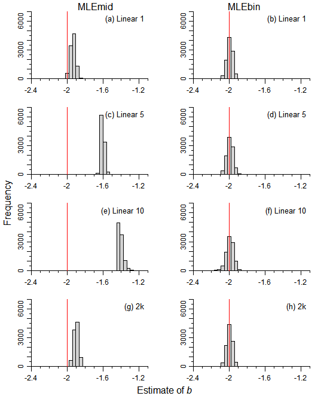

```r
MLEmid.MLEbin.hist(MLEbin.MEPS.default)
```

Figure 5 gives the confidence intervals for the MLEs for both methods and all four binning types:

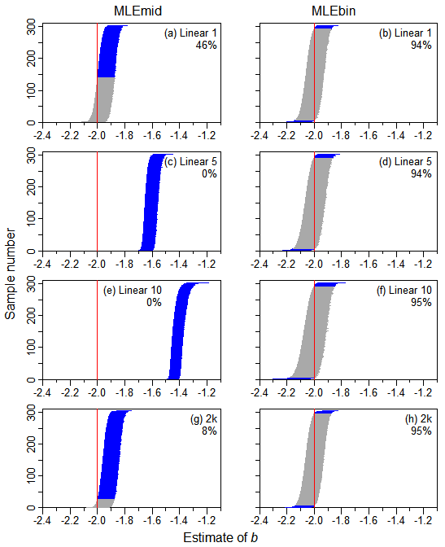

```r
# These two lines just give a different inset for panel (e):
insetMat = matrix(rep(c(-0.01, -0.04), 4),
                  ncol=2,
                  byrow=TRUE)
insetMat[3, 1] = 0.3

MLEmid.MLEbin.conf(MLEbin.MEPS.default,
                   insetMat = insetMat)
```

Make a dataframe of the results and show here, reproducing Table S.3:

```r
knitr::kable(MLEmid.MLEbin.table(MLEbin.MEPS.default))
```

| Binning.type | Method | Quantile.5 | Median | Mean | Quantile.95 | Percent.below.true |
| --- | --- | --- | --- | --- | --- | --- |
| Linear 1 | MLEmid | -1.98 | -1.94 | -1.94 | -1.89 | 1 |
| Linear 1 | MLEbin | -2.05 | -1.99 | -1.99 | -1.94 | 43 |
| Linear 5 | MLEmid | -1.63 | -1.61 | -1.6 | -1.57 | 0 |
| Linear 5 | MLEbin | -2.06 | -1.99 | -1.99 | -1.94 | 42 |
| Linear 10 | MLEmid | -1.43 | -1.41 | -1.4 | -1.35 | 0 |
| Linear 10 | MLEbin | -2.06 | -1.99 | -1.99 | -1.93 | 42 |
| 2k | MLEmid | -1.95 | -1.9 | -1.9 | -1.86 | 0 |
| 2k | MLEbin | -2.05 | -2 | -2 | -1.94 | 47 |

## Setting $x$<sub>min</sub>$=16$ – Figures S.35 and S.36 and Table S.4

Similarly, the simulation results obtained from setting $x$<sub>min</sub>$=16$ are saved in the object `MLEbin.MEPS.xmin16`, obtained by running the next line (which is not evaluated by this vignette but is run once in `data-raw/simulate-data2.R`):

```r
MLEbin.MEPS.xmin16 <- MLEbin.simulate(xmin.known = 16)
```

Figure S.35 is then

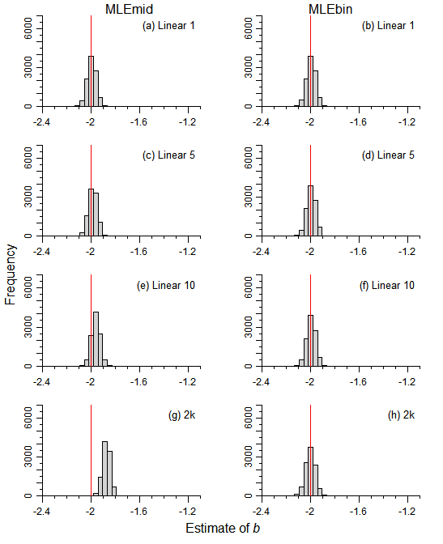

```r
MLEmid.MLEbin.hist(MLEbin.MEPS.xmin16)
```

Figure S.36 shows the confidence intervals:

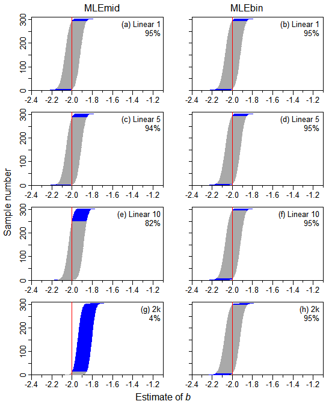

```r
MLEmid.MLEbin.conf(MLEbin.MEPS.xmin16)
```

And Table S.4 is:

```r
knitr::kable(MLEmid.MLEbin.table(MLEbin.MEPS.xmin16))
```

| Binning.type | Method | Quantile.5 | Median | Mean | Quantile.95 | Percent.below.true |
| --- | --- | --- | --- | --- | --- | --- |
| Linear 1 | MLEmid | -2.06 | -1.99 | -2 | -1.94 | 44 |
| Linear 1 | MLEbin | -2.06 | -1.99 | -2 | -1.94 | 45 |
| Linear 5 | MLEmid | -2.05 | -1.99 | -1.99 | -1.93 | 36 |
| Linear 5 | MLEbin | -2.06 | -1.99 | -2 | -1.94 | 45 |
| Linear 10 | MLEmid | -2.02 | -1.96 | -1.96 | -1.9 | 14 |
| Linear 10 | MLEbin | -2.06 | -2 | -2 | -1.94 | 45 |
| 2k | MLEmid | -1.93 | -1.87 | -1.87 | -1.82 | 0 |
| 2k | MLEbin | -2.07 | -2 | -2 | -1.94 | 51 |

## Setting $x$<sub>min</sub>$=1$ but only sampling data above the cutoff value of 16 – Figures S.37 and S.38 and Table S.5)

Similarly, the simulation results obtained from setting $x$<sub>min</sub>$=1$ again but only sampling above the cutoff value of 16 are saved in the object `MLEbin.MEPS.cutoff16`, obtained by running the next line (which is not evaluated by this vignette but is run once in `data-raw/simulate-data2.R`):

```r
MLEbin.MEPS.cutoff16 <- MLEbin.simulate(cut.off = 16)
```

Figure S.37 is then

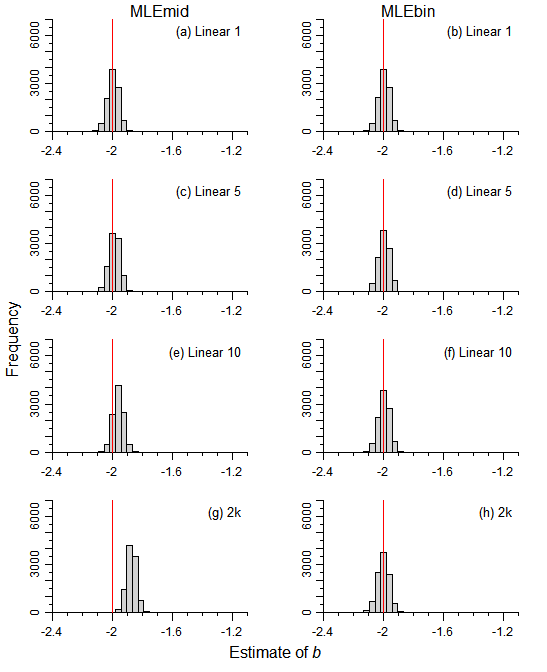

```r
MLEmid.MLEbin.hist(MLEbin.MEPS.cutoff16)
```

Figure S.38 shows the confidence intervals:

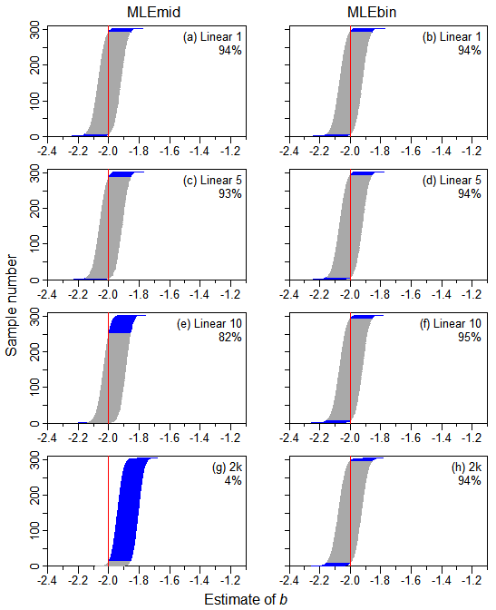

```r
MLEmid.MLEbin.conf(MLEbin.MEPS.cutoff16)
```

And Table S.5 is:

```r
knitr::kable(MLEmid.MLEbin.table(MLEbin.MEPS.cutoff16))
```

| Binning.type | Method | Quantile.5 | Median | Mean | Quantile.95 | Percent.below.true |
| --- | --- | --- | --- | --- | --- | --- |
| Linear 1 | MLEmid | -2.06 | -1.99 | -2 | -1.93 | 45 |
| Linear 1 | MLEbin | -2.06 | -1.99 | -2 | -1.94 | 45 |
| Linear 5 | MLEmid | -2.05 | -1.99 | -1.99 | -1.93 | 36 |
| Linear 5 | MLEbin | -2.06 | -2 | -2 | -1.94 | 45 |
| Linear 10 | MLEmid | -2.02 | -1.96 | -1.96 | -1.9 | 13 |
| Linear 10 | MLEbin | -2.06 | -2 | -2 | -1.93 | 46 |
| 2k | MLEmid | -1.93 | -1.87 | -1.87 | -1.82 | 0 |
| 2k | MLEbin | -2.07 | -2 | -2 | -1.94 | 51 |